# SparklyR Example code

Today we are going to try out the code from the [spraklyr](https://spark.rstudio.com/) website.

Install sparklyr R package and install Spark. Run the following commands only once.

Depending on the version of Java you have installed on your computer you many run into a problem. Hopefully not, but if you do you need to figure out what version of Java you have installed and then install a compatible version of Spark.

After you install sparklyr R package there will be Connections Tab to the right of Environment.

```r
# install.packages("sparklyr")
# spark_install()
```

```r
library(pacman)

p_load(sparklyr, tidyverse, nycflights13, Lahman)
```

Connect to Spark locally. If Spark is on another machine or on a Hadoop cluster this connection code would be different.

```r
library(sparklyr)
library(dplyr)
sc <- spark_connect(master = "local")
```

```
* Using Spark: 3.0.0
```

Copy some data to Spark and make some tables.

```r
iris_tbl <- copy_to(sc, iris)
flights_tbl <- copy_to(sc, nycflights13::flights, "flights")
batting_tbl <- copy_to(sc, Lahman::Batting, "batting")
src_tbls(sc)
```

```
[1] "batting" "flights" "iris"
```

Run *dplyr* commands on data tables on Spark.

| year | month | day | dep_time | sched_dep_time | dep_delay | arr_time | sched_arr_time | arr_delay | carrier | flight | tailnum | origin | dest | air_time | distance | hour | minute | time_hour |
| --- | --- | --- | --- | --- | --- | --- | --- | --- | --- | --- | --- | --- | --- | --- | --- | --- | --- | --- |
| 2013 | 1 | 1 | 517 | 515 | 2 | 830 | 819 | 11 | UA | 1545 | N14228 | EWR | IAH | 227 | 1400 | 5 | 15 | 2013-01-01 10:00:00 |
| 2013 | 1 | 1 | 542 | 540 | 2 | 923 | 850 | 33 | AA | 1141 | N619AA | JFK | MIA | 160 | 1089 | 5 | 40 | 2013-01-01 10:00:00 |
| 2013 | 1 | 1 | 702 | 700 | 2 | 1058 | 1014 | 44 | B6 | 671 | N779JB | JFK | LAX | 381 | 2475 | 7 | 0 | 2013-01-01 12:00:00 |
| 2013 | 1 | 1 | 715 | 713 | 2 | 911 | 850 | 21 | UA | 544 | N841UA | EWR | ORD | 156 | 719 | 7 | 13 | 2013-01-01 12:00:00 |
| 2013 | 1 | 1 | 752 | 750 | 2 | 1025 | 1029 | -4 | UA | 477 | N511UA | LGA | DEN | 249 | 1620 | 7 | 50 | 2013-01-01 12:00:00 |
| 2013 | 1 | 1 | 917 | 915 | 2 | 1206 | 1211 | -5 | B6 | 41 | N568JB | JFK | MCO | 145 | 944 | 9 | 15 | 2013-01-01 14:00:00 |
| 2013 | 1 | 1 | 932 | 930 | 2 | 1219 | 1225 | -6 | VX | 251 | N641VA | JFK | LAS | 324 | 2248 | 9 | 30 | 2013-01-01 14:00:00 |
| 2013 | 1 | 1 | 1028 | 1026 | 2 | 1350 | 1339 | 11 | UA | 1004 | N76508 | LGA | IAH | 237 | 1416 | 10 | 26 | 2013-01-01 15:00:00 |
| 2013 | 1 | 1 | 1042 | 1040 | 2 | 1325 | 1326 | -1 | B6 | 31 | N529JB | JFK | MCO | 142 | 944 | 10 | 40 | 2013-01-01 15:00:00 |
| 2013 | 1 | 1 | 1231 | 1229 | 2 | 1523 | 1529 | -6 | UA | 428 | N402UA | EWR | FLL | 156 | 1065 | 12 | 29 | 2013-01-01 17:00:00 |

[output cut: 990 more lines]

Notice the *collect()* command. This is the same as *disk.frame* code. The querry is done on Spark and the output is brought into R’s environment so a plot can be made.

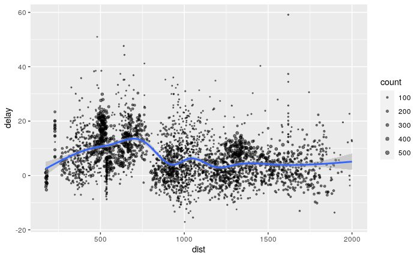

```r
delay <- flights_tbl %>%
  group_by(tailnum) %>%
  summarise(count = n(), dist = mean(distance), delay = mean(arr_delay)) %>%
  filter(count > 20, dist < 2000, !is.na(delay)) %>%
  collect

ggplot(delay, aes(dist, delay)) +
  geom_point(aes(size = count), alpha = 1/2) +
  geom_smooth() +
  scale_size_area(max_size = 2)
```

SQL querries can be run directly on Spark.

| Sepal_Length | Sepal_Width | Petal_Length | Petal_Width | Species |
| --- | --- | --- | --- | --- |
| 5.1 | 3.5 | 1.4 | 0.2 | setosa |
| 4.9 | 3.0 | 1.4 | 0.2 | setosa |
| 4.7 | 3.2 | 1.3 | 0.2 | setosa |
| 4.6 | 3.1 | 1.5 | 0.2 | setosa |
| 5.0 | 3.6 | 1.4 | 0.2 | setosa |
| 5.4 | 3.9 | 1.7 | 0.4 | setosa |
| 4.6 | 3.4 | 1.4 | 0.3 | setosa |
| 5.0 | 3.4 | 1.5 | 0.2 | setosa |
| 4.4 | 2.9 | 1.4 | 0.2 | setosa |
| 4.9 | 3.1 | 1.5 | 0.1 | setosa |

## Machine Learning can be run on Spark.

```r
summary(fit)
```

```
Deviance Residuals:
    Min      1Q  Median      3Q     Max
-2.5134 -0.9158 -0.1683  1.1503  2.1534

Coefficients:
(Intercept)          wt         cyl
 37.1464554  -4.3408005  -0.5830515

R-Squared: 0.9428
Root Mean Squared Error: 1.409
```

## Cashing data

You can pull data directly in R in memory from Spark.

```r
tbl_cache(sc, "batting")
```

```r
tbl_uncache(sc, "batting")
```

## Web interface

```r
spark_web(sc)
```

## Exiting Spark

The last thing to do is to disconnect from the Spark server.

```r
spark_disconnect(sc)
```